# 2020 Presidential Election Prediction

Michael Onuoha

October 6, 2020

## Introduction

For the upcoming 2020 presidential election, not only do I want to project whether Biden or Trump will win the election, but I also want to determine how close the election will be. In other words, I am trying to determine whether the winner will win by a landslide or win by a narrow margin. In order to make my projection, I will perform several simulations that will produce various scenarios for the election and create a density plot to determine the closeness of the final outcome. The dataset is a collection of polls and is from the [FiveThirtyEight website](https://projects.fivethirtyeight.com/2020-election-forecast/). I chose this dataset because it is aggregated, sourced reliably, and has a sufficient diversity of elements.

## Data Overview

|  | Description of Variable |
| --- | --- |
| state | The name of the state |
| pollster | The name of the pollster |
| sponsors | The name of the sponsor for the pollster |
| fte_grade | The reliability grade for the pollster |
| sample_size | The sample size of those surveyed for the pollster |
| methodology | The method that the pollster used to conduct surveys |
| start_date | The first day of the polling |
| end_date | The last day of polling |
| answer | The name of the presidential candidate |
| pct | Voteshare for the corresponding candidate in the poll |

### Levels/Distributions for Each Variable

This is the list of states:

```
##  [1] "Alabama"              "Alaska"               "Arizona"
##  [4] "Arkansas"             "California"           "Colorado"
##  [7] "Connecticut"          "Delaware"             "District of Columbia"
## [10] "Florida"              "Georgia"              "Hawaii"
## [13] "Idaho"                "Illinois"             "Indiana"
## [16] "Iowa"                 "Kansas"               "Kentucky"
## [19] "Louisiana"            "Maine"                "Maine CD-1"
## [22] "Maine CD-2"           "Maryland"             "Massachusetts"
## [25] "Michigan"             "Minnesota"            "Mississippi"
## [28] "Missouri"             "Montana"              "Nebraska"
## [31] "Nebraska CD-1"        "Nebraska CD-2"        "Nevada"
## [34] "New Hampshire"        "New Jersey"           "New Mexico"
## [37] "New York"             "North Carolina"       "North Dakota"
## [40] "Ohio"                 "Oklahoma"             "Oregon"
## [43] "Pennsylvania"         "Rhode Island"         "South Carolina"
## [46] "South Dakota"         "Tennessee"            "Texas"
## [49] "Utah"                 "Vermont"              "Virginia"
## [52] "Washington"           "West Virginia"        "Wisconsin"
## [55] "Wyoming"
```

This is the list of reliability grades as well as their distribution:

```
##  [1] "A"   "A-"  "A/B" "A+"  "B"   "B-"  "B/C" "B+"  "C"   "C-"  "C/D" "C+"
## [13] "D-"
```

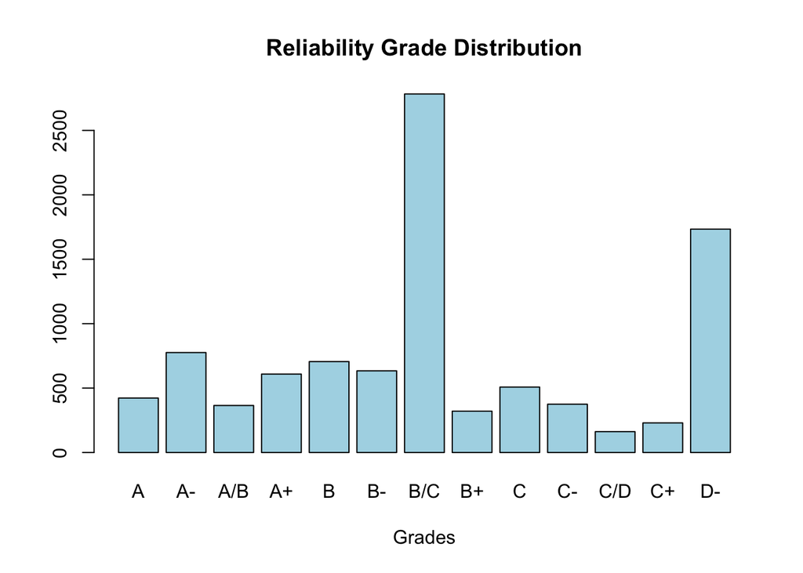

This is the distribution for the sample sizes:

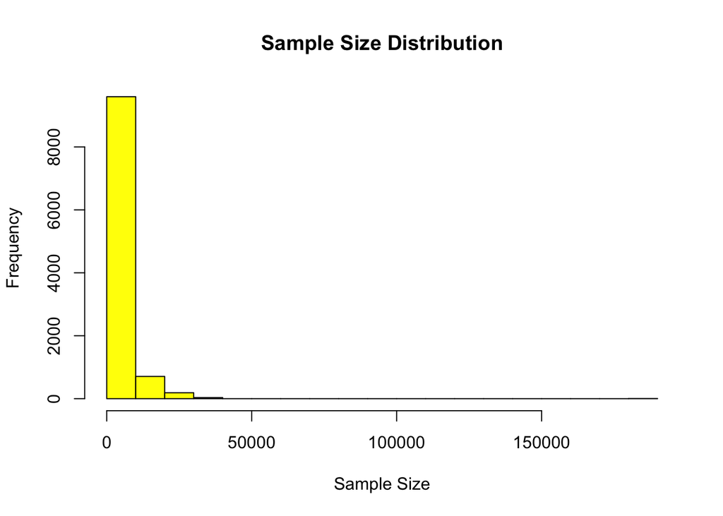

This is the list of methodologies as well as their distribution:

```
##  [1] "Automated Phone"        "IVR/Live Phone"         "IVR/Live Phone/Online"
##  [4] "IVR/Online"             "IVR/Online/Text"        "IVR/Text"
##  [7] "Live Phone"             "Live Phone/Online"      "Live Phone/Online/Text"
## [10] "Live Phone/Text"        "Mail"                   "Online"
## [13] "Online/IVR"             "Online/Text"            "Text"
```

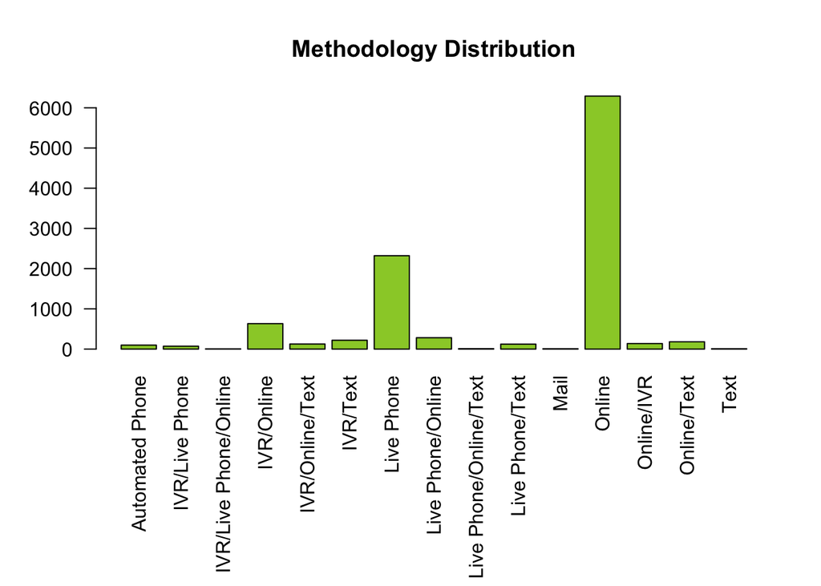

This is the distribution of the start dates:

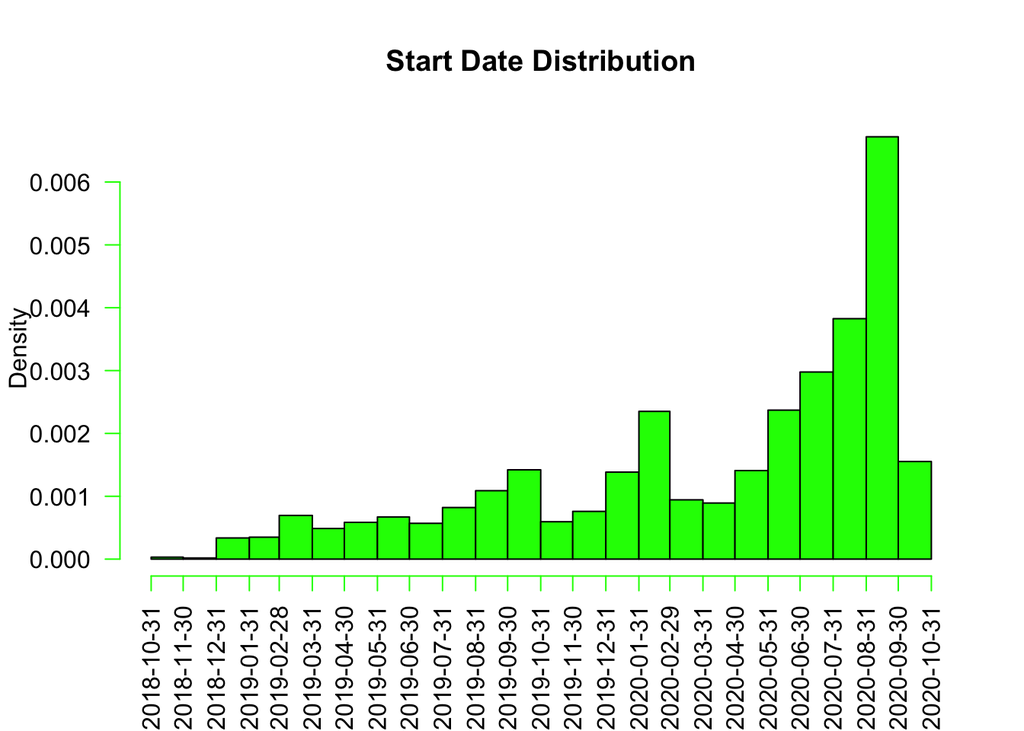

This is the distribution of the end dates:

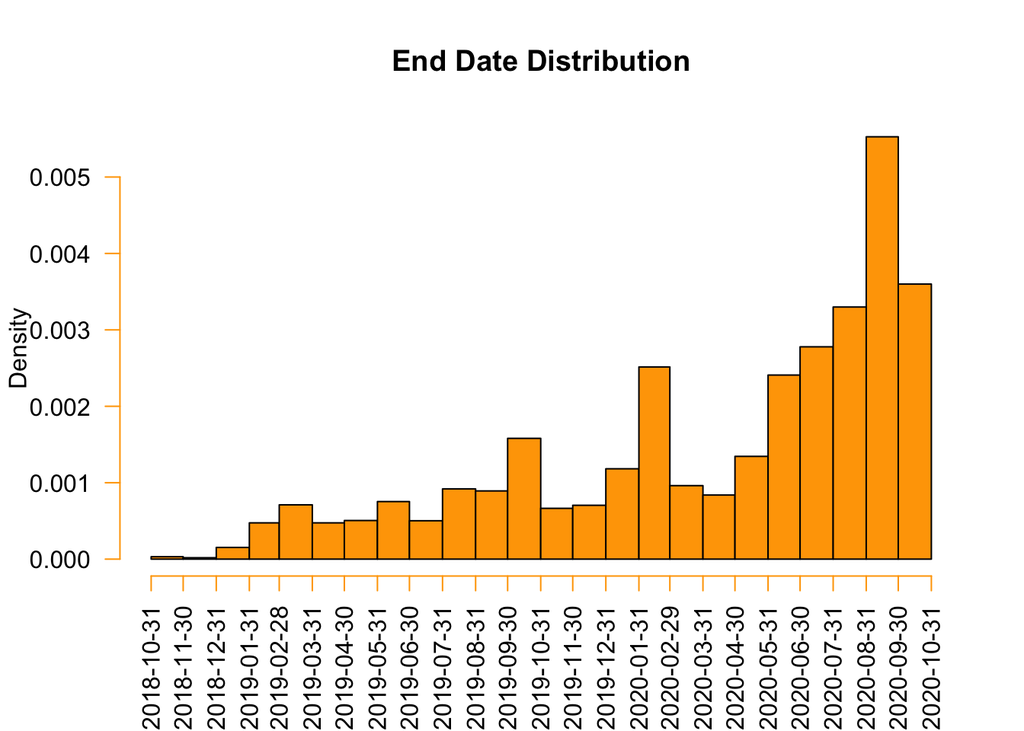

This is the list of presidential candidates:

```
##  [1] "Amash"         "Bennet"        "Biden"         "Blankenship"
##  [5] "Bloomberg"     "Booker"        "Brown"         "Bullock"
##  [9] "Buttigieg"     "Castro"        "Clinton"       "Cuomo"
## [13] "de Blasio"     "De La Fuente"  "Delaney"       "Gabbard"
## [17] "Gillibrand"    "Gravel"        "Haley"         "Harris"
## [21] "Hawkins"       "Hickenlooper"  "Hornberger"    "Inslee"
## [25] "Jorgensen"     "Kennedy"       "Klobuchar"     "La Riva"
## [29] "Messam"        "Moulton"       "O'Rourke"      "Obama"
## [33] "Ocasio-Cortez" "Pelosi"        "Pence"         "Pierce"
## [37] "Rapinoe"       "Ryan"          "Sanders"       "Schultz"
## [41] "Schumer"       "Simmons"       "Steyer"        "Swalwell"
## [45] "Trump"         "Warren"        "West"          "Williamson"
## [49] "Winfrey"       "Yang"
```

*Note: Only Biden and Trump will be used in my analysis.*

This is the distribution of the percentage of poll participants who chose Biden:

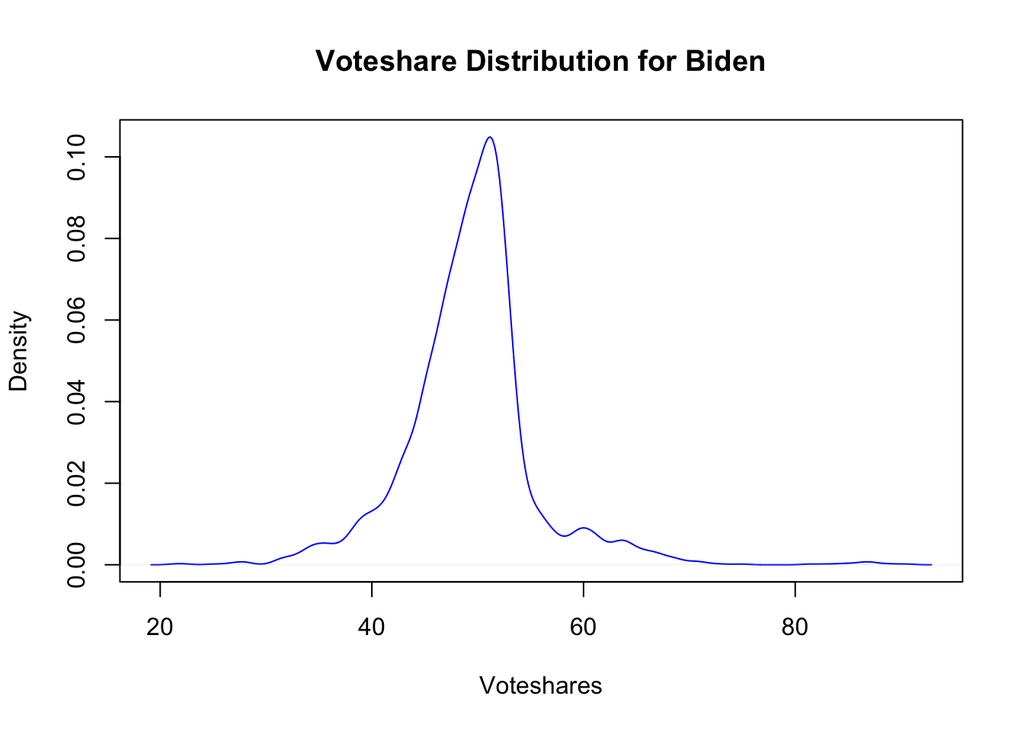

This is the distribution of the percentage of poll participants who chose Trump:

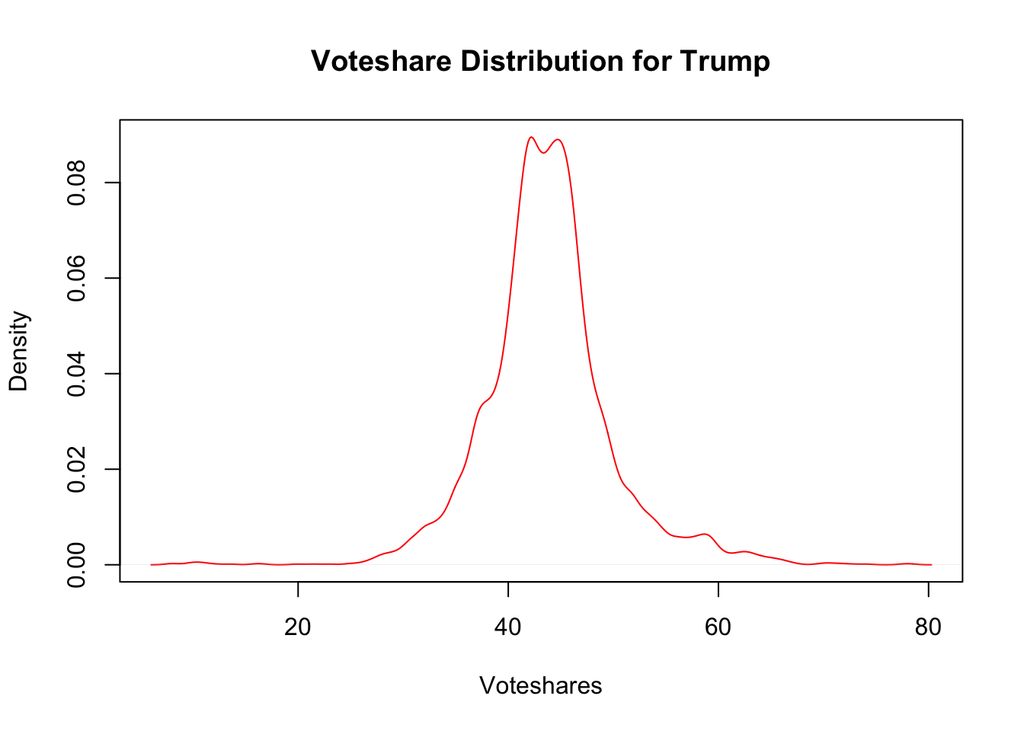

## Data Cleaning Pipeline

Although the elements in the dataset are diverse, I want to ensure that for the variables crucial for my projections (states, reliability grades, and methodologies), only the elements useful for my analysis remain in the final cleaned dataset. For instance, I kept the rows not containing NA elements for the three variables. I also ensured that only the rows containing the following grades are included in the final dataset: A+, A, A-, A/B, B+, B, B-, B/C, C+, C, and C-. These grades show the pollsters included in my analysis are reliable. I then ensured that only polling dates in 2020 are included and that these dates are between two and ten days. Since the Democratic and Republican parties are the major parties, I also ensured that the final dataset only includes Biden and Trump. However, after keeping all of the useful rows, I discovered that there are some states that are no longer accounted for, so I added enough rows to resolve the issue even though they fail to satisfy the criteria mentioned earlier. Finally, I ensured that the minimum sample size number is 375 to make my data more sufficient.

## Simulation Process

After modifying the dataset, I created a table consisting of the average voteshares for Biden and Trump in each state along with their variances and confidence intervals. The table also includes the number of electoral votes associated with each state.

|  | trump_mean | trump_var | biden_mean | biden_var | ci_trump_1 | ci_trump_2 | ci_biden_1 | ci_biden_2 | electoral |
| --- | --- | --- | --- | --- | --- | --- | --- | --- | --- |
| Alabama | 54.25000 | 22.9166667 | 39.25000 | 11.583333 | 44.867214 | 63.63279 | 32.57928 | 45.92072 | 9 |
| Alaska | 48.50000 | 4.5000000 | 46.00000 | 8.994497 | 44.342212 | 52.65779 | 40.12180 | 51.87820 | 3 |
| Arizona | 44.85727 | 5.8937276 | 48.04891 | 4.451202 | 40.098981 | 49.61556 | 43.91373 | 52.18409 | 11 |
| Arkansas | 51.50000 | 40.5000000 | 43.00000 | 8.000000 | 39.026636 | 63.97336 | 37.45628 | 48.54372 | 6 |
| California | 33.02200 | 13.2750622 | 59.03100 | 3.487166 | 25.880748 | 40.16325 | 55.37091 | 62.69109 | 55 |
| Colorado | 40.18182 | 3.3636364 | 51.63636 | 3.654545 | 36.587135 | 43.77650 | 47.88946 | 55.38327 | 9 |
| Connecticut | 33.03333 | 1.1033333 | 51.76667 | 18.963333 | 30.974556 | 35.09211 | 43.23147 | 60.30186 | 7 |
| Delaware | 36.60000 | 25.9200000 | 60.45000 | 41.405000 | 26.621309 | 46.57869 | 47.83804 | 73.06196 | 3 |
| District of Columbia | 10.50000 | 0.5000000 | 87.00000 | 2.000000 | 9.114071 | 11.88593 | 84.22814 | 89.77186 | 3 |
| Florida | 45.25190 | 7.5542673 | 48.50905 | 4.180864 | 39.864839 | 50.63897 | 44.50140 | 52.51669 | 29 |
| Georgia | 46.88974 | 3.1800675 | 46.69158 | 4.917311 | 43.394519 | 50.38495 | 42.34528 | 51.03788 | 16 |
| Hawaii | 32.00000 | 18.0000000 | 59.50000 | 24.500000 | 23.684424 | 40.31558 | 49.79850 | 69.20150 | 4 |
| Idaho | 59.33000 | 0.2178000 | 36.24000 | 6.195200 | 58.415287 | 60.24471 | 31.36153 | 41.11847 | 4 |
| Illinois | 38.40000 | 3.9200000 | 56.45000 | 25.205000 | 34.519398 | 42.28060 | 46.60990 | 66.29010 | 20 |
| Indiana | 51.60000 | 6.8000000 | 39.40000 | 2.300000 | 46.488945 | 56.71105 | 36.42751 | 42.37249 | 11 |
| Iowa | 46.87208 | 6.1196607 | 45.43750 | 5.811141 | 42.023446 | 51.72072 | 40.71266 | 50.16234 | 6 |
| Kansas | 50.00000 | 3.6000000 | 42.16667 | 2.966667 | 46.281162 | 53.71884 | 38.79076 | 45.54257 | 6 |
| Kentucky | 55.69889 | 10.8235111 | 37.17444 | 6.811378 | 49.250664 | 62.14711 | 32.05912 | 42.28977 | 8 |
| Louisiana | 51.60000 | 9.6866667 | 39.70000 | 11.286667 | 45.499812 | 57.70019 | 33.11526 | 46.28474 | 8 |
| Maine | 39.48000 | 3.6551111 | 52.82000 | 8.564000 | 35.732804 | 43.22720 | 47.08419 | 58.55581 | 2 |
| Maine CD-1 | 31.00000 | 2.0000000 | 62.50000 | 4.500000 | 28.228141 | 33.77186 | 58.34221 | 66.65779 | 1 |
| Maine CD-2 | 44.66667 | 0.3333333 | 48.00000 | 21.000000 | 43.535060 | 45.79827 | 39.01815 | 56.98185 | 1 |
| Maryland | 31.57500 | 7.7225000 | 60.77500 | 1.469167 | 26.128280 | 37.02172 | 58.39930 | 63.15070 | 10 |
| Massachusetts | 27.71200 | 9.0347200 | 61.28800 | 29.954720 | 21.820669 | 33.60333 | 50.56074 | 72.01526 | 11 |
| Michigan | 42.47424 | 8.6369417 | 48.90045 | 6.300134 | 36.714062 | 48.23442 | 43.98084 | 53.82007 | 16 |
| Minnesota | 42.50000 | 6.8234783 | 49.81250 | 8.017663 | 37.380130 | 47.61987 | 44.26267 | 55.36233 | 10 |
| Mississippi | 53.00000 | 9.0000000 | 41.33333 | 2.333333 | 47.120000 | 58.88000 | 38.33938 | 44.32728 | 6 |
| Missouri | 49.41667 | 3.7456667 | 44.45000 | 8.375000 | 45.623337 | 53.21000 | 38.77784 | 50.12216 | 10 |
| Montana | 51.59667 | 10.3360267 | 43.50167 | 2.272017 | 45.295327 | 57.89801 | 40.54732 | 46.45602 | 3 |
| Nebraska | 51.50000 | 0.5000000 | 46.50000 | 0.500000 | 50.114071 | 52.88593 | 45.11407 | 47.88593 | 2 |
| Nebraska CD-1 | 48.00000 | 8.2913236 | 46.00000 | 8.667424 | 42.356247 | 53.64375 | 40.22966 | 51.77034 | 1 |
| Nebraska CD-2 | 42.83333 | 2.9666667 | 51.00000 | 2.800000 | 39.457426 | 46.20924 | 47.72029 | 54.27971 | 1 |
| Nevada | 42.43333 | 8.3150000 | 48.30000 | 7.585000 | 36.781528 | 48.08514 | 42.90199 | 53.69801 | 6 |
| New Hampshire | 43.36154 | 4.2958974 | 50.19231 | 19.730769 | 39.299135 | 47.42394 | 41.48612 | 58.89850 | 4 |
| New Jersey | 35.51444 | 6.3818778 | 54.09889 | 3.755511 | 30.563018 | 40.46587 | 50.30058 | 57.89720 | 14 |
| New Mexico | 42.35000 | 22.4450000 | 54.15000 | 0.045000 | 33.064274 | 51.63573 | 53.73422 | 54.56578 | 5 |
| New York | 31.85714 | 5.8095238 | 58.28571 | 12.904762 | 27.132964 | 36.58132 | 51.24477 | 65.32666 | 29 |
| North Carolina | 45.81200 | 3.8716191 | 47.66343 | 4.228623 | 41.955420 | 49.66858 | 43.63296 | 51.69390 | 15 |
| North Dakota | 55.60000 | 8.8000000 | 36.80000 | 2.700000 | 49.785700 | 61.41430 | 33.57939 | 40.02061 | 3 |
| Ohio | 46.87375 | 6.3075810 | 46.23042 | 4.045769 | 41.951230 | 51.79627 | 42.28805 | 50.17278 | 18 |
| Oklahoma | 60.80000 | 2.8800000 | 34.60000 | 0.720000 | 57.473770 | 64.12623 | 32.93688 | 36.26312 | 7 |
| Oregon | 39.00000 | 8.6042037 | 53.50000 | 12.500000 | 33.250747 | 44.74925 | 46.57035 | 60.42965 | 7 |
| Pennsylvania | 43.67000 | 4.9840741 | 49.56488 | 6.121440 | 39.294292 | 48.04571 | 44.71554 | 54.41422 | 20 |
| Rhode Island | 32.50000 | 0.5000000 | 66.50000 | 0.500000 | 31.114071 | 33.88593 | 65.11407 | 67.88593 | 4 |
| South Carolina | 50.04000 | 4.4811429 | 43.32000 | 3.136000 | 45.890933 | 54.18907 | 39.84908 | 46.79092 | 9 |
| South Dakota | 56.00000 | 8.6042037 | 42.50000 | 0.500000 | 50.250747 | 61.74925 | 41.11407 | 43.88593 | 3 |
| Tennessee | 54.00000 | 2.0000000 | 37.50000 | 4.500000 | 51.228141 | 56.77186 | 33.34221 | 41.65779 | 11 |
| Texas | 46.87302 | 7.1086978 | 45.15744 | 4.276139 | 41.647244 | 52.09880 | 41.10439 | 49.21049 | 38 |
| Utah | 48.41667 | 6.6287879 | 36.66667 | 16.060606 | 43.370366 | 53.46297 | 28.81183 | 44.52150 | 6 |
| Vermont | 33.23000 | 1.1858000 | 59.86500 | 34.196450 | 31.095669 | 35.36433 | 48.40336 | 71.32664 | 3 |
| Virginia | 40.20000 | 1.7000000 | 51.00000 | 4.000000 | 37.644473 | 42.75553 | 47.08000 | 54.92000 | 13 |
| Washington | 32.60000 | 9.8000000 | 57.80000 | 6.700000 | 26.464229 | 38.73577 | 52.72667 | 62.87333 | 12 |
| West Virginia | 59.50000 | 84.5000000 | 35.00000 | 32.000000 | 41.482919 | 77.51708 | 23.91257 | 46.08743 | 5 |
| Wisconsin | 43.27141 | 2.6076273 | 49.16030 | 4.029981 | 40.106370 | 46.43644 | 45.22564 | 53.09496 | 10 |
| Wyoming | 62.50000 | 0.5000000 | 36.00000 | 8.994497 | 61.114071 | 63.88593 | 30.12180 | 41.87820 | 3 |

I then used the table to perform 1000 simulations which will help me discover the likely winner of the election. The diagram describing the simulation process is shown below.

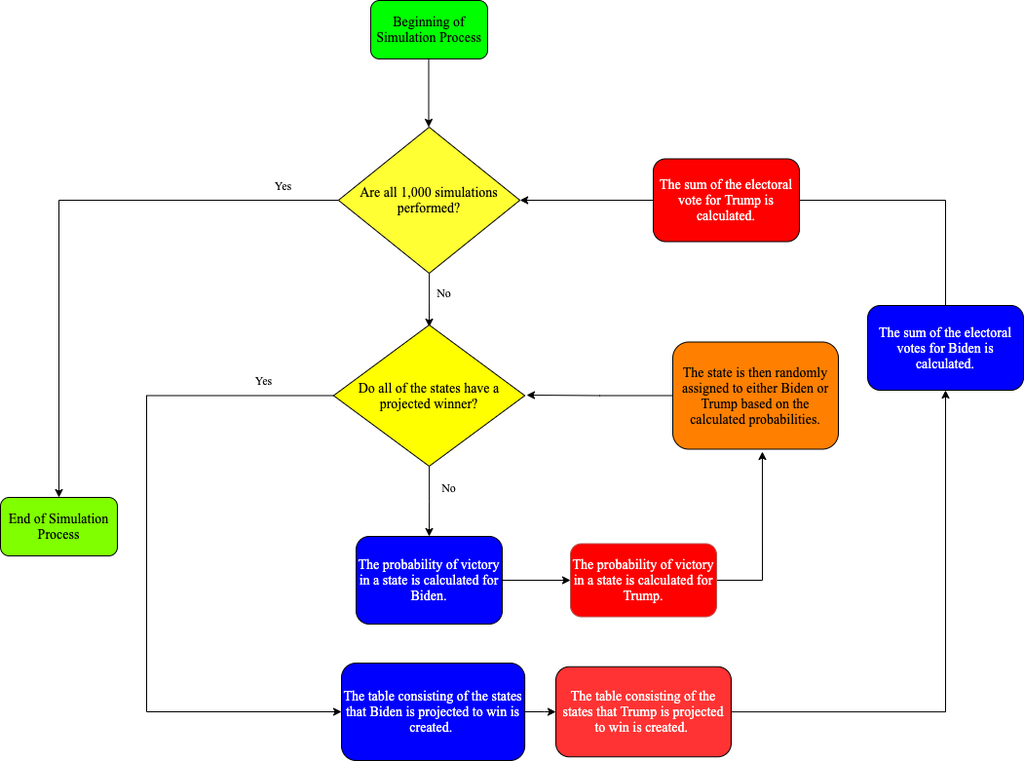

The code for the simulation is below:

```r
#let's perform 1000 simulations for the "coin toss" states
for(j in 1:1000){
  for(i in 1:nrow(state_dist2)){
    prob_trump = state_dist2[i, 'trump_mean']/(state_dist2[i, 'trump_mean'] + state_dist2[i, 'biden_mean'])
    prob_biden = state_dist2[i, 'biden_mean']/(state_dist2[i, 'trump_mean'] + state_dist2[i, 'biden_mean'])
    temp_winner = sample(c(0, 1), 1, prob = c(prob_trump, prob_biden))
    state_dist2[i, 'bin_winner'] = temp_winner
  }
  state_dist_trump = state_dist2[(state_dist2$bin_winner == 0),] #dataset with the coin toss states that Trump is likely to win
  state_dist_biden = state_dist2[(state_dist2$bin_winner == 1),] #dataset with the coin toss states that Biden is likely to win
  #add up the electoral values for each candidate
  trump_elec = sum(state_dist_trump$electoral)
  biden_elec = sum(state_dist_biden$electoral)
  trump_elec1 = as.integer(trump_elec)
  biden_elec1 = as.integer(biden_elec)
  #the electoral votes for each candidate in each simulation are aggregated
  election_result[j, "Trump"] = trump_elec1
  election_result[j, "Biden"] = biden_elec1
  election_result[j, "winner"] = ifelse(biden_elec1 > trump_elec1, 'Biden', 'Trump')
  election_result1 = election_result[complete.cases(election_result),]
}
```

## Results

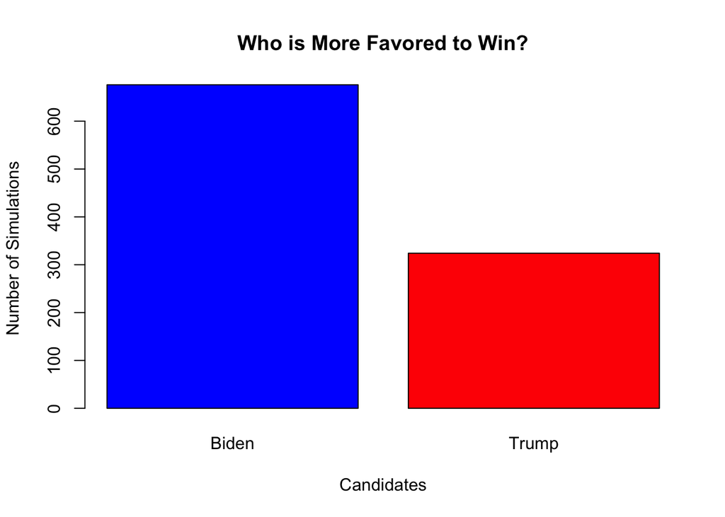

Based on the bar graph above, this is the number of simulations out of 1000 in which Biden is projected to win:

```
## [1] 676
```

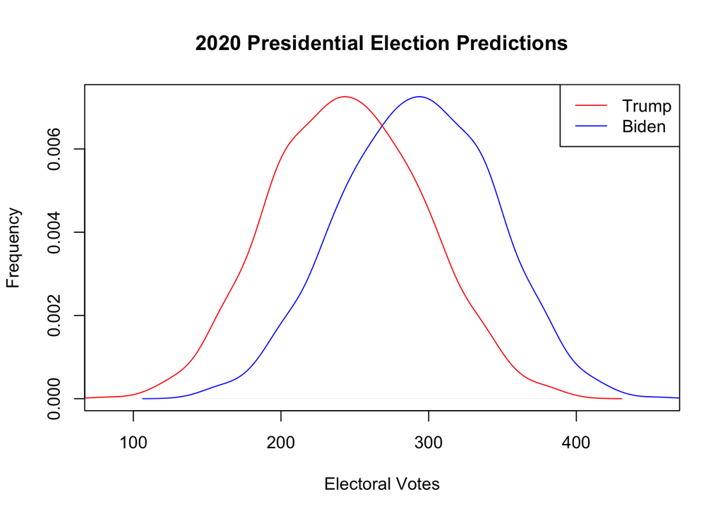

Based on the density plot above, this is the number of electoral votes that Biden is most likely to win:

```
## [1] 293
```

And this is the number of electoral votes that Trump is most likely to win:

```
## [1] 243
```

## Discussion

Based on the bar graph and density plot, Biden is favored to win the 2020 presidential election. When predicting the outcome of the election, there were many scenarios to take into account. Therefore, it was helpful to perform the 1000 simulations to discover which scenarios would benefit each candidate so that the winner could be predicted based on who had the most favorable scenarios. The density plot was also useful because the two curves represent the distribution of electoral votes for each candidate based on the simulations.

In conducting my analysis, it was important to pay attention to the following states projected to have close races:

```
##  [1] "Florida"        "Arizona"        "North Carolina" "Michigan"
##  [5] "Pennsylvania"   "New Hampshire"  "Georgia"        "Ohio"
##  [9] "Wisconsin"      "South Carolina" "Minnesota"      "Texas"
## [13] "Nevada"         "Iowa"           "Montana"        "Louisiana"
## [17] "West Virginia"  "Utah"           "Alaska"         "Missouri"
## [21] "Maine CD-2"     "Alabama"        "Nebraska CD-1"  "Arkansas"
```

## Post-Election Discussion

Based on the actual election results, which show that Biden won by 306 electoral votes whereas Trump won by 232 votes, my projections were correct in the sense that the former would win the election. However, the margin was not as narrow as I projected. One reason can be that 26,668,887 more Americans voted this year (a 20.7% increase from the 2016 election), and most of them voted by mail due to the COVID-19 pandemic. Another reason can be that some people who participated in the polling surveys did not vote in this election; and similarly, some people who did not participate in the surveys still voted. In fact, the latter reason might be more significant because the pre-election polling process usually fails to provide reliable predictions of who would win the presidency. Therefore, for future elections, it would be best to weight polling data less than other strong indicators for predicting the outcome.